# Money, prices and the exchange rate

Session 1

Luis F. Gómez L.

luis.gomezl@unimilitar.edu.co

Distance Learning Faculty

10 February, 2026

# Please Read Me

- Check the message **Welcome greeting** published in Announcements forum.
- Dear student please edit your profile uploading a photo where your face is clearly visible.
- If you want to participate, please fill out the following survey: **Primer corte 30% > Learning Activities > Tu opinión sobre la economía colombiana**
- This presentation is based on (Cardenas, 2020, Chapter 7)
- **Purpose**
  - Analyze the money market and introduce the concepts of inflation, nominal exchange rate and interest rate

# Money and Central Banks

- Money is an **asset**[^1] that fulfills in general 3 functions
  - Medium of exchange
  - Unit of account
  - Store of value
- *“A central bank[^2] is the institution that issues and administrates legal currency and exercises the function of banker of banks”* (República, 2021)
- In the case of Colombia, some of the functions of the central bank are (Banrep, 2025a):
  - Maintain a low and stable inflation rate in order to preserve the purchasing power of money (**Monetary Policy - Política monetaria**)
  - Intervene in the foreign exchange market in such a way that the interventions are consistent with the inflation targeting strategy (**Foreign exchange intervention policy - Política de intervención cambiaria**).
  - Regulate the activity of credit institutions, control the liquidity of the financial system and ensure the proper functioning of payments in the economy (**Credit policity - Política crediticia**).
- In the case of Colombia, some of the functions of the central bank are (Banrep, 2025a):
  - Manage the international reserves[^3] (**Reservas internacionales**)
  - Lender of last resort for credit institutions (**Prestamista de última instancia de los establecimientos de crédito**)
  - Support the government in certain economic operations for the management of its liquidity, its payments, and its financial portfolio (**Government fiscal agent - Agente fiscal del gobierno**)

Table 1: Establishment date of central banking institutions (Herger, 2019, p. 15)

| Bank | Established |
| --- | --- |
| Sveriges Riksbank | 1668 |
| Bank of England | 1694 |
| Banque de France | 1800 |
| Bank of Finland | 1800 |
| Nederlandsche Bank | 1814 |
| Austrian National Bank | 1816 |
| Norges Bank | 1816 |
| Danmarks Nationalbank | 1818 |
| Banco de Portugal | 1846 |
| Belgian National Bank | 1850 |
| Banco de España | 1874 |
| German Reichsbank | 1876 |
| Bank of Japan | 1882 |
| Banca d’Italia | 1893 |
| Banco de la Republica (Colombia) | 1923 |

# Inflation and Consumer Price Index

- **Inflation** is a persistent increase in the price level:
  - Inflation refers to a general increase in the price level
  - This increase must be persistent
  - A measure that represents the behavior of the price level is required where it is necessary to specify a basket of products
- Review the videos found in:
  - **Tercer corte 40% > Learning Resources > Links of interest**
- The **price level** is an **index number** (Ralph et al., 2015)
  - An **index number** is a quantity that by varying shows the changes of a magnitude over time or space
- The variation in the **price level** from one period to another is used to measure inflation
- The value that the index number takes to measure the **price level** will depend on the products that are taken into account in the basket that is used
- Usually the **price level** used to measure inflation in Colombia is called **Indice de Precios al Consumidor (IPC)** or **Consumer Price Index (CPI)**
  - In Colombia, this index measures the average variation of the prices of a basket of products representative of household consumption (DANE, 2019)
  - You can check out the historical basket of products included in the **(IPC)** or **(CPI)** in: (DANE, 2019) > Información adicional > Estructura histórica de ponderaciones y canasta de seguimiento del IPC
- The **CPI** is build using information from **Encuesta Nacional de Presupuesto de los Hogares –ENPH- (2016-2017)** where it is conducted every 10 years (DANE, 2019, Section 2.1.5).
- Additionally, usually monthly, but in some cases bimonthly, quadrimestral and biannual, price information is collected for approximately 443[^4] items in 38 cities where divisions included in the **CPI** are based on **Classification of Individual Consumption According to Purpose (COICOP)** (United Nations, 2000) [^5] and adapted for Colombia.

Table 2: COICOP divisions (International version) 1999

| Division | Name |
| --- | --- |
| 01 | Food and non-alcoholic beverages |
| 02 | Alcoholic beverages, tobacco and narcotics |
| 03 | Clothing and footwear |
| 04 | Housing, water, electricity, gas and other fuels |
| 05 | Furnishings, household equipment and routine household maintenance |
| 06 | Health |
| 07 | Transport |
| 08 | Communication |
| 09 | Recreation, sport and culture |
| 10 | Education |
| 11 | Restaurants and hotels |
| 12 | Miscellaneous goods and services |

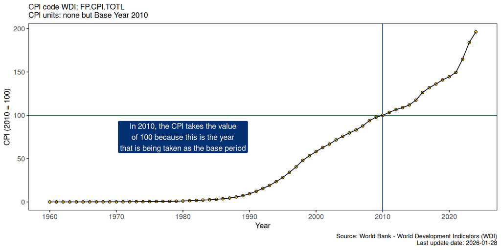

Figure 1: Colombia Consumer price index (CPI)

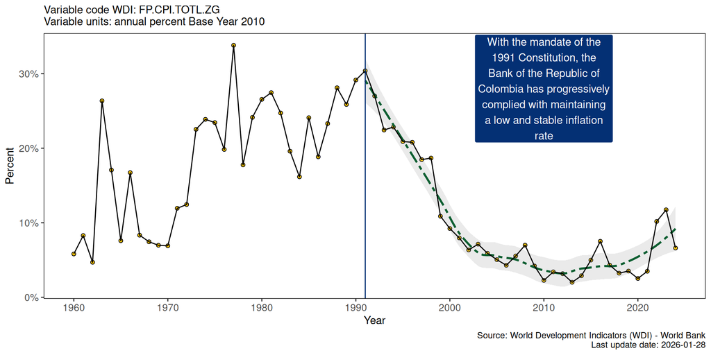

Figure 2: Inflation using Consumer price index (CPI) for Colombia

- Calculating inflation using the **Consumer Price Index (CPI)**
  - CPI annual periodicity

    $$Inflation_t = \frac{CPI_t - CPI_{t-1}}{CPI_{t-1}} \times 100$$
  - CPI monthly periodicity

    $$Inflation_t = \frac{CPI_t - CPI_{t-12}}{CPI_{t-12}} \times 100$$
- An exchange rate is the amount of **units of national currency** that must be given in exchange for a **unit of foreign currency**
- If the exchange rate between COP[^6] and USD[^7] is 3652 COP/USD, it means that 3652 COP must be given to obtain 1 USD
- To have a reference of the exchange rate between COP and USD, the **“Superintendencia Financiera de Colombia (SFC)”** currently calculates and certifies an *average* exchange rate called **“Tasa Representativa del Mercado (TRM)”** on a daily basis
- Also it is important to take into account the following terminology:
  - **Devaluation**: TRM - COP/USD $(\Uparrow)$
  - **Revaluation**: TRM - COP/USD $(\Downarrow)$

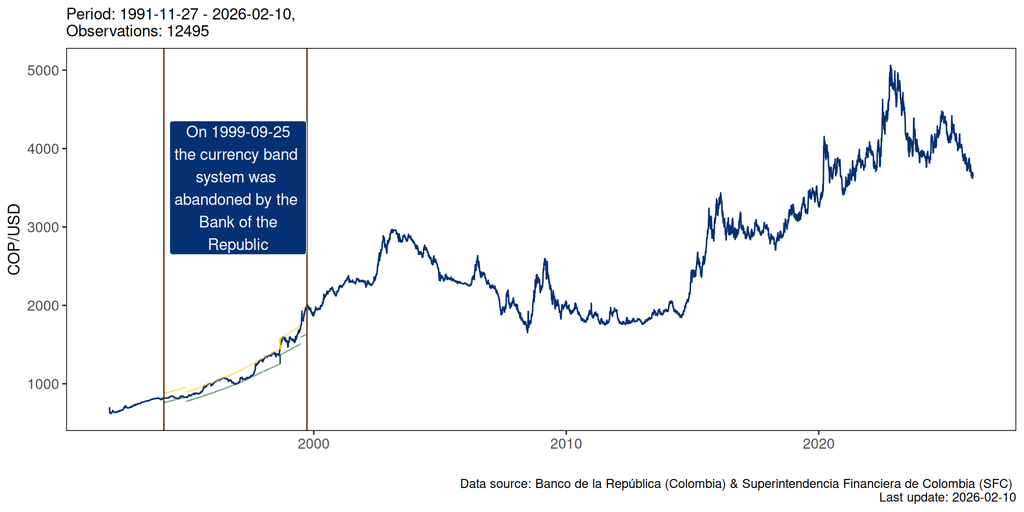

Figure 3: Daily Tasa Representativa del Mercado - TRM (COP/USD)

# Acknowledgments

- To my family that supports me
- To the taxpayers of Colombia and the [**UMNG students**](https://www.umng.edu.co/estudiante) who pay my salary
- To the [**Business Science**](https://www.business-science.io/) and [**R4DS Online Learning**](https://www.rfordatasci.com/) communities where I learn [**R**](https://www.r-project.org/about.html) and [**$\pi$-thon**](https://www.python.org/about/)
- To the [**R Core Team**](https://www.r-project.org/contributors.html), the creators of [**RStudio IDE**](https://posit.co/download/rstudio-desktop/), [**Positron**](https://positron.posit.co/), [**Quarto**](https://quarto.org/) and the authors and maintainers of the packages [**tidyverse**](https://CRAN.R-project.org/package=tidyverse), [**gt**](https://CRAN.R-project.org/package=gt), [**wbstats**](https://CRAN.R-project.org/package=wbstats), [**scales**](https://CRAN.R-project.org/package=scales) and [**tinytex**](https://CRAN.R-project.org/package=tinytex) for allowing me to access these tools without paying for a license

# References

Banrep. (2025a). *Funciones del Banco de la República Banco de la República*. https://www.banrep.gov.co/es/banco/funciones

Banrep. (2025b). *Reservas internacionales Banco de la República*. https://www.banrep.gov.co/es/politica-monetaria-cambiaria/reservas-internacionales

Cardenas, M. (2020). *Introducción a la Economía Colombiana* (4th ed.). Alfaomega.

DANE. (2019). *Metodología General índice de Precios al Consumidor - IPC*. Dirección de Metodología y Producción Estadística - DIMPE. https://www.dane.gov.co/index.php/estadisticas-por-tema/precios-y-costos/indice-de-precios-al-consumidor-ipc/ipc-informacion-tecnica

Herger, N. (2019). *Understanding Central Banks*. Springer International Publishing. https://doi.org/10.1007/978-3-030-05162-4

IFRS. (2018). *Conceptual Framework for Financial Reporting*. https://www.ifrs.org/issued-standards/list-of-standards/conceptual-framework/

Nations, U. (2023). *Classification of Individual Consumption According to Purpose (COICOP) 2018*. https://unstats.un.org/unsd/classifications/Econ/Download/COICOP_2018_pre_copy_edit_publication.pdf

Ralph, J., O’Neill, R., & Winton, J. (2015). *A practical introduction to index numbers*. Wiley.

República, B. de la. (2021). *A Central Bank Banco de la República*. https://www.banrep.gov.co/en/node/7599

United Nations (Ed.). (2000). *Classifications of expenditure according to purpose: Classification of the functions of government (COFOG), classification of individual consumption according to purpose (COICOP), classification of the purposes of non-profit institutions serving households (COPNI), classification of the outlays of producers according to purpose (COPP)*. United Nations.

## Footnotes

[^1]: This part is important because for example a credit card can fulfills the 3 functions but it is not an asset as defined by (IFRS, 2018, Chapter 4)
[^2]: For a list of central banks around the world see [**https://www.bis.org/cbanks.htm**](https://www.bis.org/cbanks.htm)
[^3]: For more information about the international reserves you can check out (Banrep, 2025b)
[^4]: This can change sometimes every year
[^5]: An update version (Nations, 2023) is not used according to (DANE, 2019, Section 2.1.5, g.)
[^6]: Colombian peso according to ISO 4217 code
[^7]: United States dollar according to ISO 4217 code